# Generative models of online discussion threads

Welcome to our [ICWSM-19 tutorial](https://icwsm.org/2019/program/tutorial/) on generative models of online discussion threads. The tutorial is based on the survey:

- [Aragón, P., Gómez, V., Garcı́a, D. & Kaltenbrunner, A. Generative models of online discussion threads: state of the art and research challenges. J. Internet Serv. Appl. 8, 15 (2017). DOI 10.1186/s13174-017-0066-z](https://jisajournal.springeropen.com/articles/10.1186/s13174-017-0066-z)

This notebook is based on the [genthreads](https://github.com/alumbreras/generative-discussion-threads/) R package developed by [Alberto Lumbreras](https://github.com/alumbreras/) and then extended in collaboration with [Matteo Manca](https://github.com/matteomanca).

The purpose of this notebook is to provide tutorial attendeeds with computational and statistical tools to:

- Represent data from online discussion threads using array structures
- Visualize online discussion threads as tree networks
- Apply different generative models of online discussion threads:
  - [Gómez et al. 2013](https://doi.org/10.1007/s11280-012-0162-8)
  - [Aragón et al. 2017](https://aaai.org/ocs/index.php/ICWSM/ICWSM17/paper/view/15609)
- Validate generative models through structural properties:
  - Degree
  - Subtree (cascade) size
  - Depth

# Getting started

First of all, download R Studio from

- https://www.rstudio.com/

Open R Studio and install some R packages we will need:

```r
  # install.packages("igraph")      # Classic R package for graphs
  # install.packages("ggplot2")     # Classic R package for plots
  # install.packages("tidyr")       # Classic R package to manipulate data
  # install.packages("dplyr")       # Classic R package to manipulate data
  # install.packages("dfoptim")     # R package with Nelder-Mead optimizer
  # install.packages("foreach")     # R package for the foreach looping construct
  # install.packages("doParallel")  # R package for the %dopar% function using the parallel package
```

It is time now to download the R package, there are two options:

- if you have git: `git clone https://github.com/elaragon/generative-discussion-threads.git`
- otherwise: download and unzip https://github.com/elaragon/generative-discussion-threads/archive/master.zip

Launch R Studio and open any file from our package, for instance:

```
analysis/Tutorial ICWSM/notebook.Rmd
```

and then tell R to make this directory its working directory:

```
Session -> Set Working Directory -> To Source File Location
```

Finally, tell R to load the package.

```r
devtools::load_all() # load the functions of the package
```

# Representation of online discussion threads

Asychronous conversations on the Internet are often represented as threads, which are initiated by a user posting a starting message and then users send replies to either the initial message or to the existing replies. Therefore, given this sequential posting behavior, online discussion threads follow a tree network structure.

### Basic data structures

We will first learn how to represent the structure and dynamics of an online conversations in a very simple way: a **parents vector**. The parents vector is a vector $\boldsymbol{\pi} = (\pi_1,...,\pi_2)$ where $\pi_t$ contains the parent of node $t$. Our package contains a function that plots the tree corresponding to a parents vector.

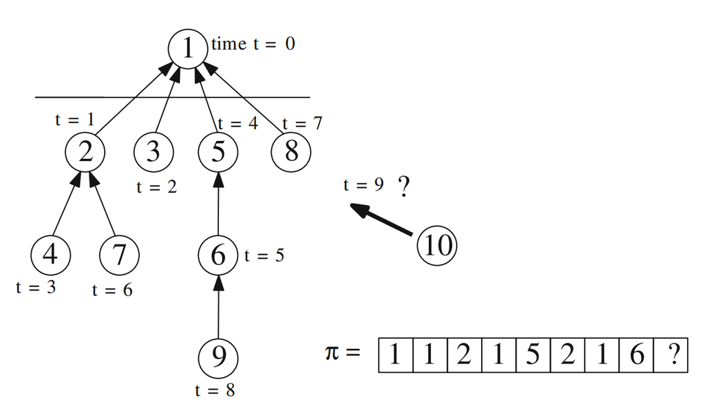

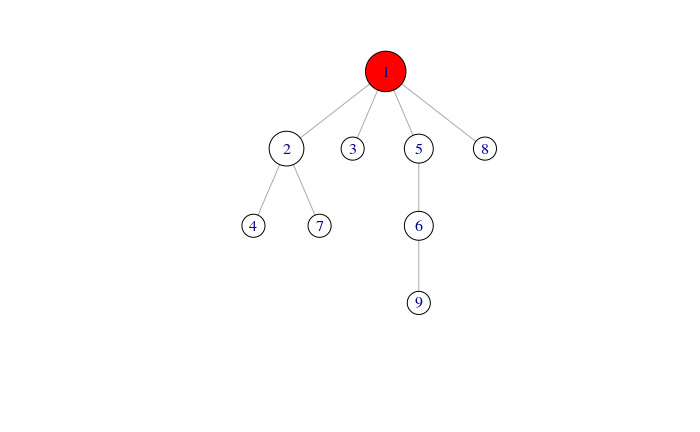

```r
# Vector representation
parents           <- c(1,1,2,1,5,2,1,6)

# Plot it as a tree
gtree             <- parents_to_tree(parents)
V(gtree)[1]$color <- "red"                      # except the root (initial message)
deg <- degree(gtree, mode="all")
gtree.un          <- as.undirected(gtree)
la                <- layout_as_tree(gtree.un, mode='out', root=1)
plot(gtree.un, layout = la, vertex.size=15+deg*5)
```

This structure is valid for any discussion thread. Thus, you will be able to use this package as soon as you represent collections of threads as a list of parent vectors.

Although parents vector is the basic structure, our package convert these vectors into dataframes with some metadata that can be easily deduced from the parents vector and which will be needed by the generative models of online discussion threads. For instance, to transform our parents vector into a dataframe:

```r
# Vector representation
parents   <- c(1,1,2,1,5,2,1,6)

# Dataframe representation. Easy to make computations
df.thread <- parents_to_dataframe(parents)
df.thread
```

| post | t | parent | popularity | root | lag |
| --- | --- | --- | --- | --- | --- |
| 2 | 1 | 1 | 0 | 1 | 1 |
| 3 | 2 | 1 | 1 | 1 | 2 |
| 4 | 3 | 2 | 1 | 0 | 2 |
| 5 | 4 | 1 | 2 | 1 | 4 |
| 6 | 5 | 5 | 1 | 0 | 1 |
| 7 | 6 | 2 | 2 | 0 | 5 |
| 8 | 7 | 1 | 3 | 1 | 7 |
| 9 | 8 | 6 | 1 | 0 | 3 |

where:

```
* post:           id of the node
* t:              time steps in which the node appeared (root appears at t=0)
* parent:         id of parent node
* popularity:     degree of parent node just before this node appeared
* root:           1 if the parent node is the root
* lag (recency):  time steps elapsed since the parent post appeared.
```

Given a list of parent vectors, we can also compute:

- the degree distribution

```r
p = c()
p[[1]] = c(1,1,2,1,5,2,1,6)
struct_degree_distribution(p)
```

| degree | frequency |
| --- | --- |
| 0 | 5 |
| 1 | 2 |
| 2 | 1 |
| 3 | 0 |
| 4 | 1 |

- the subtree size distribution:

```r
struct_subtree_size_distribution(p)
```

| size | frequency |
| --- | --- |
| 0 | 5 |
| 1 | 1 |
| 2 | 2 |
| 3 | 0 |
| 4 | 0 |
| 5 | 0 |
| 6 | 0 |
| 7 | 0 |
| 8 | 1 |

- the depth distribution

```r
struct_depth_distribution(p)
```

| depth | frequency |
| --- | --- |
| 0 | 1 |
| 1 | 4 |
| 2 | 3 |
| 3 | 1 |

### Loading real online discussion threads from Meneame

Discussion threads in this tutorial come from [Aragón, P., Gómez, V., & Kaltenbrunner, A. (2017). To Thread or Not to Thread: The Impact of Conversation Threading on Online Discussion. ICWSM 2017 – The International AAAI Conference on Web and Social Media, Montreal, Canada.](https://aaai.org/ocs/index.php/ICWSM/ICWSM17/paper/view/15609).

There is a CSV file for each discussion thread in May 2015 at *data/meneame/*. Rows are comments listed chronologically and columns are parent_id (initial message is 0), depth, user, parent_user. The dataset is fully available at [Zenodo](https://zenodo.org/record/2536218#.XP1Wv59fhdY). Threads are preprocessed with the script *analysis/Tutorial ICWSM/meneame_preprocessing.R* which stores the threads as a dataframe df.trees in the file *data/meneame.df.trees.rda*

- **Extra:** Given the increasing interest in discussion threads from Reddit, we have also developed the script *analysis/Tutorial ICWSM/reddit_preprocessing.R*. This script parses monthly JSON dumps from http://files.pushshift.io/reddit/ as the ones stored at *data/gameofthrones/* corresponding to discussions in 2018 at the [Game of Thrones subreddit](https://www.reddit.com/r/gameofthrones/) (dumps were downloaded with the bash script *data/reddit-discussions-2018.bash*)

First, we load the data, convert them into parent vectors, and then plot some of them

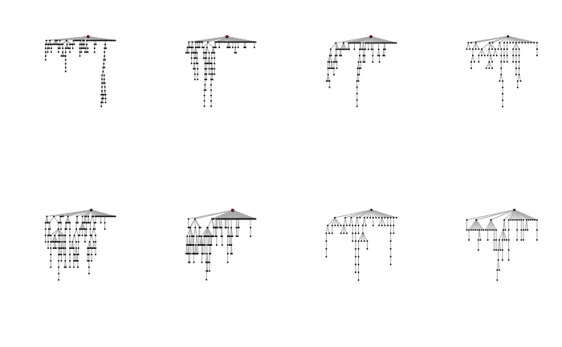

```r
data("meneame.df.trees")

# Create dataframe structure with the largest threads
df.trees <- df.trees %>%  group_by(thread) %>% filter(n()>=70) %>%  ungroup %>% arrange(thread, t)

parents = c()
threads = unique(df.trees$thread)
for (i in 1:length(threads)) {
  parents[[i]] = (df.trees %>% filter(thread==threads[i]))$parent
}

# Plot some threads in tree and graph representations
par(mfrow = c(2,4))
for(i in 1:8){
  gtree <- parents_to_tree(parents[[i]])
  V(gtree)[1]$color <- "red" # except the root (initial message)
  deg <- degree(gtree, mode="all")
  gtree.un          <- as.undirected(gtree)
  la                <- layout_as_tree(gtree.un, mode='out', root=1)
  plot(gtree.un,
       layout = la,
       vertex.size=sqrt(deg),
       vertex.label=NA)
}
```

# Modeling of online discussion threads

We will start by the generative model of [Gómez, V., Kappen, H. J., Litvak, N., & Kaltenbrunner, A. (2013). A likelihood-based framework for the analysis of discussion threads. World Wide Web, 16(5-6), 645-675.](https://doi.org/10.1007/s11280-012-0162-8). In this model, when a new comment arrives to the discussion, it is attached to an existing node $j\in~1,...,t$ with probability proportional to its function $\phi_j(\cdot)$, defined as a combination of the features $\theta=(\alpha,\tau,\beta)$
$$\phi_j ( \pi_{1:t}; \theta ) := \alpha \text{deg}_j(\pi_{1:t}) + \beta\delta_{j,1} + \tau^{t+1-j}
\\
p(\pi_{t+1}=j|\pi_{1:t};\theta) \propto\phi_j(\pi_{1:t};\theta)$$
where $\text{deg}_j(\pi_{1:t})$ is the degree of node $j$ in the tree $\pi_{1:t}$ and $\delta$ is the Kronecker delta function, i.e. $\beta$ is only relevant for the root node.

Our package provides:

- the likelihood function: likelihoods.R -> likelihood_Gomez2013(df.trees, alpha, beta, tau)
- an estimation function based upon the likelihood: estimators.R -> estimation_Gomez2013(df.trees, params) (optimizes objective function likelihood_Gomez2013)
- a function to generate synthetic data: thread_generators.R -> gen.parentsvector.Gomez2013(n, alpha, beta, tau) (generates sythetic parent vectors)

Other useful files are:

- **data_structures.R**: functions to convert from parent vectors to dataframes and vice versa.
- **structural_properties.R**: functions to compute structural properties of a forum dataset (synthetic or real)
- **plot_utils.R**: functions to plot trees, etc.

### Generating synthetic threads using the model parameters

We can generate synthetic threads assigning specific values to the model parameters.

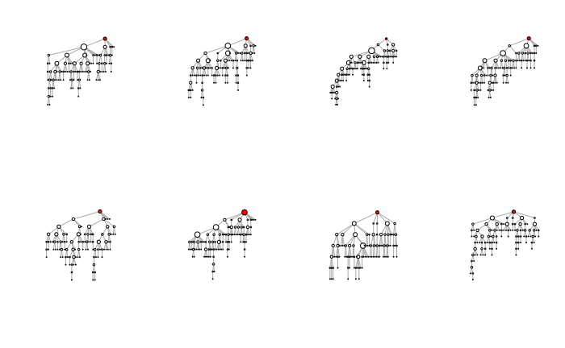

```r
alpha <- 0
beta <- 0
tau <- 1
ntrees <- 8
n = 100
parents <- replicate(ntrees,
                     gen.parentsvector.Gomez2013(n, alpha, beta, tau),
                     simplify = FALSE)

par(mfrow = c(2,4))
for(i in 1:8){
  gtree <- parents_to_tree(parents[[i]])
  V(gtree)[1]$color <- "red" # except the root (initial message)
  deg <- degree(gtree, mode="all")
  gtree.un          <- as.undirected(gtree)
  la                <- layout_as_tree(gtree.un, mode='out', root=1)
  plot(gtree.un, layout = la, vertex.size=deg*2, vertex.label=NA)
}
```

**Let’s tune the parameters to better understand this generative model**

On the one hand, if we want to emphasize the role of popularity (messages with many replies will attract new replies), we should increase $\alpha$.

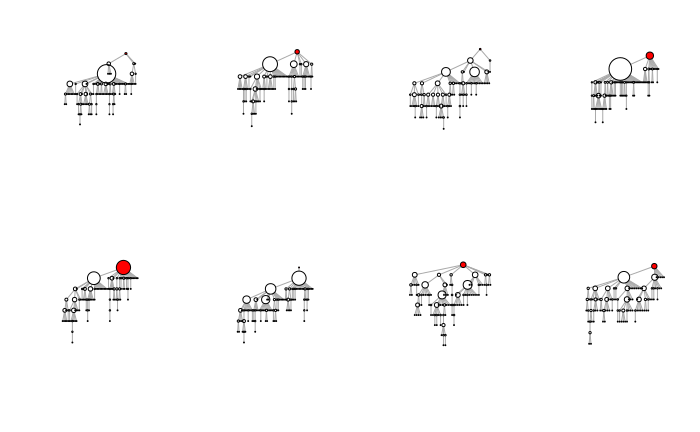

```r
alpha <- 4
beta <- 0
tau <- 1
ntrees <- 8
n = 100
parents <- replicate(ntrees,
                     gen.parentsvector.Gomez2013(n, alpha, beta, tau),
                     simplify = FALSE)

par(mfrow = c(2,4))
for(i in 1:8){
  gtree <- parents_to_tree(parents[[i]])
  V(gtree)[1]$color <- "red" # except the root (initial message)
  deg <- degree(gtree, mode="all")
  gtree.un          <- as.undirected(gtree)
  la                <- layout_as_tree(gtree.un, mode='out', root=1)
  plot(gtree.un, layout = la, vertex.size=deg*2, vertex.label=NA)
}
```

On the other hand, if we want to emphasize novelty (newest messages will attract new replies), we should set $\tau$ close to 0.

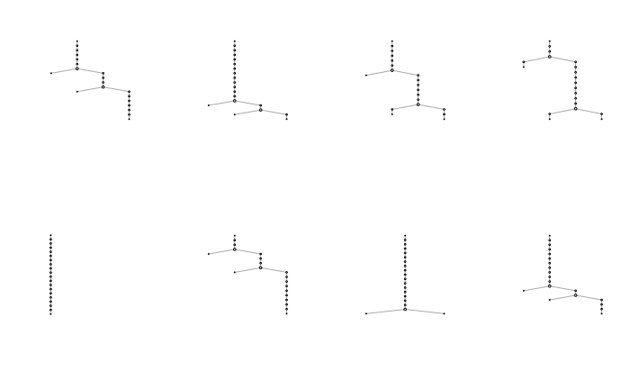

```r
alpha <- 0
beta <- 0
tau <- 0.1
ntrees <- 8
n = 20
parents <- replicate(ntrees,
                     gen.parentsvector.Gomez2013(n, alpha, beta, tau),
                     simplify = FALSE)

par(mfrow = c(2,4))
for(i in 1:8){
  gtree <- parents_to_tree(parents[[i]])
  V(gtree)[1]$color <- "red" # except the root (initial message)
  deg <- degree(gtree, mode="all")
  gtree.un          <- as.undirected(gtree)
  la                <- layout_as_tree(gtree.un, mode='out', root=1)
  plot(gtree.un, layout = la, vertex.size=deg*2, vertex.label=NA)
}
```

Finally, if we want to make the root (initial message) very attractive to new replies, we should increase $\beta$ instead.

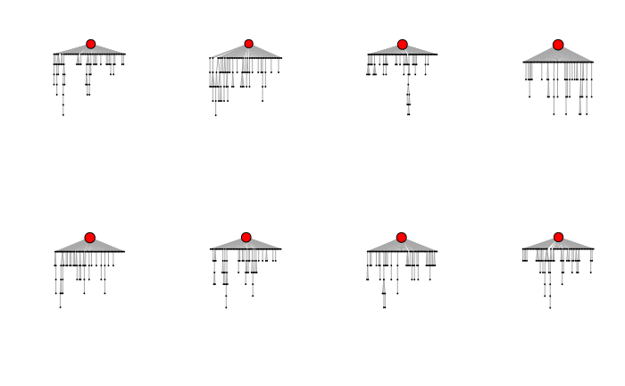

```r
alpha <- 0
beta <- 8
tau <- 0.9
ntrees <- 8
n = 100
parents <- replicate(ntrees,
                     gen.parentsvector.Gomez2013(n, alpha, beta, tau),
                     simplify = FALSE)

par(mfrow = c(2,4))
for(i in 1:8){
  gtree <- parents_to_tree(parents[[i]])
  V(gtree)[1]$color <- "red" # except the root (initial message)
  deg <- degree(gtree, mode="all")
  gtree.un          <- as.undirected(gtree)
  la                <- layout_as_tree(gtree.un, mode='out', root=1)
  plot(gtree.un, layout = la, vertex.size=1+deg/2, vertex.label=NA)
}
```

## Sanity check

The values used above were useful to generate synthetic threads at random or by increasing the value of the parameters.

Now let’s try more realistic values $(\alpha=0.5, \beta=1, \tau=0.8)$.

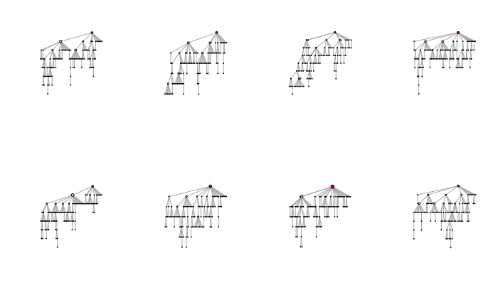

```r
alpha <- 0.5
beta <- 1
tau <- 0.8
ntrees <- 500
n = 100
parents <- replicate(ntrees,
                     gen.parentsvector.Gomez2013(n, alpha, beta, tau),
                     simplify = FALSE)

par(mfrow = c(2,4))
for(i in 1:8){
  gtree <- parents_to_tree(parents[[i]])
  V(gtree)[1]$color <- "red" # except the root (initial message)
  deg <- degree(gtree, mode="all")
  gtree.un          <- as.undirected(gtree)
  la                <- layout_as_tree(gtree.un, mode='out', root=1)
  plot(gtree.un, layout = la, vertex.size=1+deg/2, vertex.label=NA)
}
```

Before fitting our model to real data, we will perform a sanity check to validate that we can estimate these exact parameter values of our synthetic trees. First, let check whether the likelihood function for a given parameter given the others peaks around the true value:

For $\alpha$, we should obtain $0.5$:

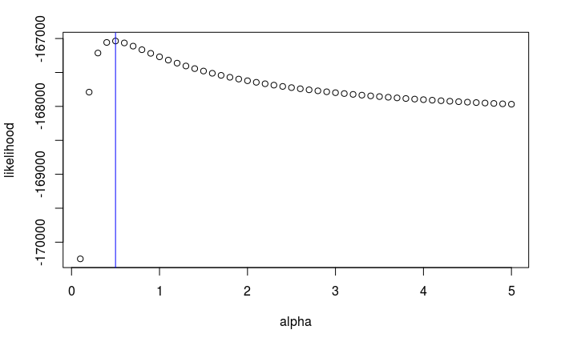

```r
par(mfrow = c(1,1))

df.trees <- all_parents_to_dataframe(parents)

alpha_grid <- seq(0.1,5, by = 0.1)
likelihood <- rep(NA, length(alpha_grid))
for(i in 1:length(alpha_grid)){
  params <- list(alpha=alpha_grid[i],beta=beta,tau=tau)
  likelihood[i] <- likelihood_Gomez2013(df.trees, params)
}
plot(alpha_grid, likelihood, xlab = 'alpha')
abline(v=alpha, col = 'blue')
```

For $\beta$, we should obtain $1$

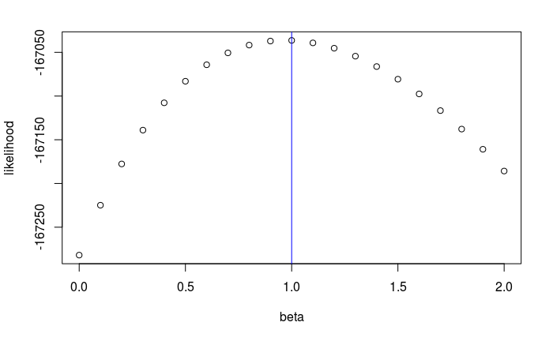

```r
beta_grid <- seq(0,2, by = 0.1)
likelihood <- rep(NA, length(beta_grid))
for(i in 1:length(beta_grid)){
  params <- list(alpha=alpha,beta=beta_grid[i],tau=tau)
  likelihood[i] <- likelihood_Gomez2013(df.trees, params)
}
plot(beta_grid, likelihood, xlab = 'beta')
abline(v=beta, col = 'blue')
```

For $\tau$, we should obtain $0.8$:

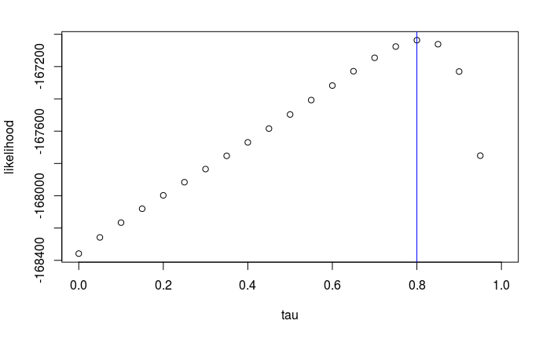

```r
tau_grid <- seq(0,1, by = 0.05)
likelihood <- rep(NA, length(tau_grid))
for(i in 1:length(tau_grid)){
  params <- list(alpha=alpha,beta=beta,tau=tau_grid[i])
  likelihood[i] <- likelihood_Gomez2013(df.trees, params)
}
plot(tau_grid, likelihood, xlab = 'tau')
abline(v=tau, col = 'blue')
```

Finally, we check whether we get estimate the true parameter values for different initializations and different collection sizes:

```r
alpha <- 0.5
beta <- 1
tau <- 0.8
n <- 100

df.results <- data.frame()
ntrees <- c(10, 50, 100, 500, 1000)
# For different collection sizes:
for(nt in ntrees){

  # Generate synthetic trees
  parents <- replicate(nt, gen.parentsvector.Gomez2013(n, alpha, beta, tau), simplify = FALSE)
  df.trees <- all_parents_to_dataframe(parents)

  # Estimate with different init parameters
  res <- estimation_Gomez2013(data = df.trees, params=list(alpha=runif(1), beta=runif(1)*10, tau=runif(1, max=0.99)))
  res$ntrees <- ntrees
  df.results <- rbind(df.results, estimation_Gomez2013(data = df.trees, params=list(alpha=runif(1),
                                                                                      beta=runif(1)*10,
                                                                                      tau=runif(1, max=0.99))))
}
df.results$ntrees <-ntrees
df.results
```

|  | alpha | beta | tau | likelihood | ntrees |
| --- | --- | --- | --- | --- | --- |
| 1 | 0.4785712 | 0.7810060 | 0.8119487 | -3325.562 | 10 |
| 2 | 0.5075402 | 0.8258754 | 0.7925578 | -16661.412 | 50 |
| 3 | 0.4125604 | 0.8386339 | 0.7483887 | -33276.970 | 100 |
| 4 | 0.5259814 | 0.9443577 | 0.8101043 | -167033.271 | 500 |
| 5 | 0.5035194 | 1.0027982 | 0.7993555 | -333499.847 | 1000 |

## Validation of the model model with real online discussion threads

We now estimate the parameter values of the discussion threads from Meneame:

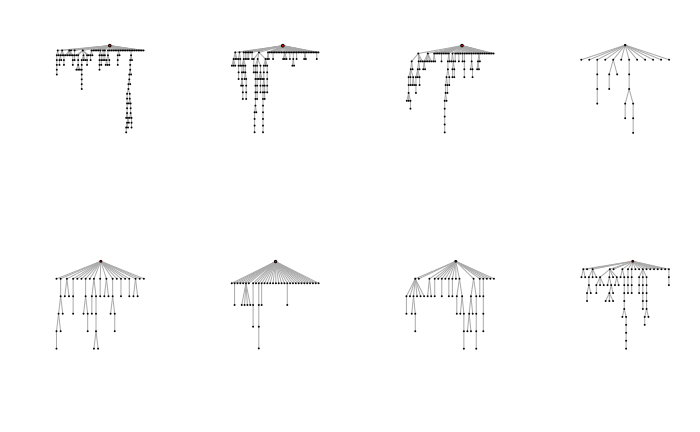

```r
data("meneame.df.trees")

# Create dataframe structure
df.trees <- df.trees %>%  group_by(thread) %>% filter(n()>=0) %>%  ungroup %>% arrange(thread, t)

parents = c()
threads = unique(df.trees$thread)
for (i in 1:length(threads)) {
  parents[[i]] = (df.trees %>% filter(thread==threads[i]))$parent
}

# Plot some threads in tree and graph representations
par(mfrow = c(2,4))
for(i in 1:8){
  gtree <- parents_to_tree(parents[[i]])
  V(gtree)[1]$color <- "red" # except the root (initial message)
  deg <- degree(gtree, mode="all")
  gtree.un          <- as.undirected(gtree)
  la                <- layout_as_tree(gtree.un, mode='out', root=1)
  plot(gtree.un,
       layout = la,
       vertex.size=sqrt(deg),
       vertex.label=NA)
}
```

```r
cat('Threads:', length(parents),'\n\n')
```

```
Threads: 1253
```

```r
# Estimate alpha, beta, tau parameters
params.Gomez2013 <- estimation_Gomez2013(data = df.trees, params=list(alpha=runif(1), beta=runif(1)*10, tau=runif(1, max=0.99)))
params.Gomez2013
```

```
$alpha
[1] 0.06444262

$beta
[1] 3.58396

$tau
[1] 0.8331392

$likelihood
[1] -291873
```

and we check whether our model generate synthetic threads with the structural properties similar to the ones of the real threads from Meneame.

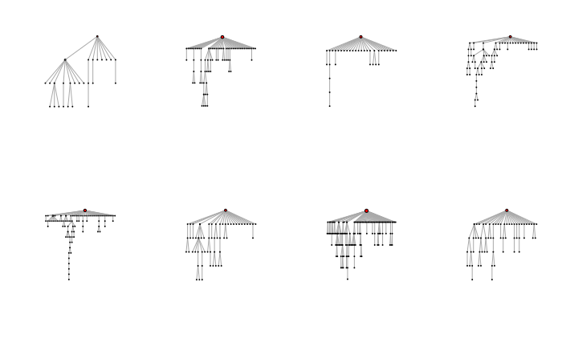

```r
# Generate threads with the estimated parameters
sizes <- (df.trees %>% group_by(thread) %>% summarise(unique = n()))$unique
sizes_sample <-  sample(sizes, length(sizes), replace=TRUE)
parents_hat.Gomez2013 <- list()
for(i in 1:length(sizes_sample)){
  parents_hat.Gomez2013[[i]] <-
    gen.parentsvector.Gomez2013(
      sizes_sample[i],
      params.Gomez2013$alpha,
      params.Gomez2013$beta,
      params.Gomez2013$tau)
}
# Plot some threads in tree and graph representations
par(mfrow = c(2,4))
for(i in 1:8){
  gtree             <- parents_to_tree(parents_hat.Gomez2013[[i]])
  V(gtree)[1]$color <- "red"  # except the root (initial message)
  deg <- degree(gtree, mode="all")
  gtree.un          <- as.undirected(gtree)
  la                <- layout_as_tree(gtree.un, mode='out', root=1)
  plot(gtree.un,
       layout = la,
       vertex.size=0+sqrt(deg*2),
       vertex.label=NA)
}
```

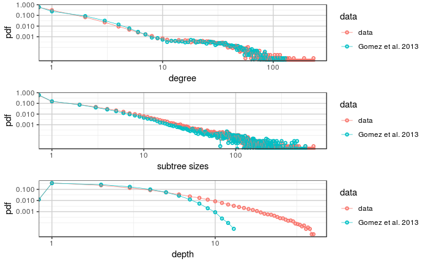

```r
# Degree distribution
df.degrees     <- struct_degree_distribution(parents)
df.degrees$prob <- df.degrees$frequency/sum(df.degrees$frequency)
df.degrees_hat.Gomez2013 <- struct_degree_distribution(parents_hat.Gomez2013)
df.degrees_hat.Gomez2013$prob <- df.degrees_hat.Gomez2013$frequency/sum(df.degrees_hat.Gomez2013$frequency)
df.degrees$cumprob     <- cumsum(df.degrees$frequency/sum(df.degrees$frequency))
df.degrees_hat.Gomez2013$cumprob <- cumsum(df.degrees_hat.Gomez2013$frequency/sum(df.degrees_hat.Gomez2013$frequency))
df.degrees$data     <- 'data'
df.degrees_hat.Gomez2013$data <- 'Gomez et al. 2013'
df.degrees_all <- bind_rows(df.degrees, df.degrees_hat.Gomez2013)
plotdegrees <- ggplot(df.degrees_all, aes(x=degree, y=cumprob, color=data)) +
  geom_point(aes(x=degree, y = prob), shape = 21, size = 1, stroke = 1) +
  geom_line(aes(x=degree, y = prob), size=0.25) +
  scale_y_log10(breaks=c(0.001,0.01,0.1,1)) +
  scale_x_log10(breaks=c(1,10,100)) +
  theme_bw() +
  theme(panel.grid.major = element_line(colour = "#d0d0d0")) +
  ylab('pdf')

# Subtree size distribution
df.subtrees     <- struct_subtree_size_distribution(parents)
df.subtrees$prob <- df.subtrees$frequency/sum(df.subtrees$frequency)
df.subtrees_hat.Gomez2013 <- struct_subtree_size_distribution(parents_hat.Gomez2013)
df.subtrees_hat.Gomez2013$prob <- df.subtrees_hat.Gomez2013$frequency/sum(df.subtrees_hat.Gomez2013$frequency)
df.subtrees$cumprob     <- cumsum(df.subtrees$frequency/sum(df.subtrees$frequency))
df.subtrees_hat.Gomez2013$cumprob <- cumsum(df.subtrees_hat.Gomez2013$frequency/sum(df.subtrees_hat.Gomez2013$frequency))
df.subtrees$data     <- 'data'
df.subtrees_hat.Gomez2013$data <- 'Gomez et al. 2013'
df.subtrees_all <- bind_rows(df.subtrees, df.subtrees_hat.Gomez2013)
plotsubtrees <- ggplot(df.subtrees_all, aes(x=size, y=cumprob, color=data)) +
  geom_point(aes(x=size, y = prob), shape = 21, size = 1, stroke = 1) +
  geom_line(aes(x=size, y = prob), size=0.25) +
  scale_y_log10(breaks=c(0.001,0.01,0.1,1)) +
  scale_x_log10(breaks=c(1,10,100)) +
  theme_bw() +
  theme(panel.grid.major = element_line(colour = "#d0d0d0")) +
  xlab ('subtree sizes') +
  ylab('pdf')

# Depth distribution
df.depths     <- struct_depth_distribution(parents)
df.depths$prob <- df.depths$frequency/sum(df.depths$frequency)
df.depths_hat.Gomez2013 <- struct_depth_distribution(parents_hat.Gomez2013)
df.depths_hat.Gomez2013$prob <- df.depths_hat.Gomez2013$frequency/sum(df.depths_hat.Gomez2013$frequency)
df.depths$cumprob     <- 1-cumsum(df.depths$frequency/sum(df.depths$frequency))
df.depths_hat.Gomez2013$cumprob <- 1-cumsum(df.depths_hat.Gomez2013$frequency/sum(df.depths_hat.Gomez2013$frequency))
df.depths$data     <- 'data'
df.depths_hat.Gomez2013$data <- 'Gomez et al. 2013'
df.depths_all <- bind_rows(df.depths, df.depths_hat.Gomez2013)
plotdepths <- ggplot(df.depths_all, aes(x=depth, y=cumprob, color=data)) +
  geom_point(aes(x=depth, y = prob), shape = 21, size = 1, stroke = 1) +
  geom_line(aes(x=depth, y = prob), size=0.25) +
  scale_y_log10(breaks=c(0.001,0.01,0.1,1)) +
  scale_x_log10(breaks=c(1,10,100)) +
  theme_bw() +
  theme(panel.grid.major = element_line(colour = "#d0d0d0")) +
  ylab('pdf')

grid.arrange(plotdegrees, plotsubtrees, plotdepths, nrow = 3)
```

## Extending the model with reciprocity

As seen above, depths using [Gómez et al. 2013](https://doi.org/10.1007/s11280-012-0162-8) are underestimated. This occurs because the model is not able to generate a typical phenomena of discussions: long chains of two users that alternate reciprocal interactions . This was the motivation for the generative model at [Aragón et al. 2017](https://aaai.org/ocs/index.php/ICWSM/ICWSM17/paper/view/15609/14789) which incorporates reciprocity as a feature.

A thread in this model is represented with the parent vector $\pi_{1:t}$ together with a vector of respective authors $a_{1:t}=~(a_1, a_2,...,a_t)$.The authorship vector will grow depending on the structure of the discussion, which in turn will depend on the authorship of the messages.

The author model does not allow two consecutive comments to be written by the same user. Furthermore, a user cannot self-reply a comment made by herself. Let $U$ denote the number of different users that participated in the conversation so far. At time $t+1$, a new comment is originated from a new user with id $U+1$ with probability $p_{new}$, or otherwise from an existing user $v$ chosen according to how many times user $v$ has been replied in the thread, $r_v$. The author model is described as
$$p(a_{t+1} = v|a_{1:t},\pi_{1:t}) = \begin{cases}
p_{new} , & \text{ for } v=U+1\\
\frac{(1-p_{new})2^{r_v}}{\sum_{i=1}^U{ 2^{r_{i}}}}, & \text{ for } v \in 1,...,U\\
\end{cases}$$
$p_{new}$ is set empirically to $t^{-1/k}$ ($k$ is estimated from the data). Notice that the preferential attachment process that selects authors is multiplicative. This is required to capture well the probability distribution of the number of comments per unique author in a thread. Once the author $a_{t+1}$ is decided, the new comment is attached to an existing comment $j$ proportionally to the extended attractiveness function $\phi'_j(\cdot)$, which now depends on the vector of authors $a_{1:t}$ and the parameters $\theta'=(\alpha,\tau,\beta,\kappa)$
$$\phi'_j(\pi_{1:t},a_{1:t};\theta') := \phi_j(\pi_{1:t};\theta) + \kappa\delta_{a_{\pi_j}, a_{t+1}}
\\
p'(\pi_{t+1}=j|\pi_{1:t},a_{1:t}; \theta') \propto \phi'_j(\pi_{1:t},a_{1:t};\theta')$$
where the additional term $\kappa\delta_{a_{\pi_j}, a_{t+1}}$ is non-zero for reciprocal comments only and $\phi_j(\cdot)$ is the original (author-independent) attractiveness function of Gómez et al. 2013. To illustrate the reciprocity feature, we create a synthetic thread with high $\kappa$:

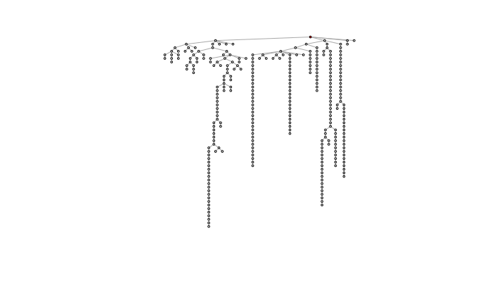

```r
alpha <- 0.2
beta <- 0.5
tau <- 0.9
kappa <- 5
n = 300
gtree <- parents_to_tree((gen.thread.Aragon2017(n, alpha, beta, tau, kappa, k=2))$parent)
V(gtree)[1]$color <- "red" # except the root (initial message)
deg <- degree(gtree, mode="all")
gtree.un          <- as.undirected(gtree)
la                <- layout_as_tree(gtree.un, mode='out', root=1)
plot(gtree.un, layout = la, vertex.size=2, vertex.label=NA)
```

The introduction of reciprocity led us to generate the typical chains of pairs of users exchanging messages. Our package provides:

- the likelihood function: likelihoods.R -> likelihoods.R -> likelihood_Aragon2017(df.trees, alpha, beta, tau, kappa)
- an estimation function based upon the likelihood: estimators.R -> estimation_Aragon2017(df.trees, params){ (optimizes objective function likelihood_Aragon2017)
- a function to generate synthetic data: thread_generators.R -> gen.thread.Aragon2017(n, alpha, beta, tau, kappa, k) (generates sythetic parent vectors)

We now estimate the parameter values from the same Meneame discussion threads (**note:** this process might last several minutes so it is recommended to store the estimated values in a .rda file for future executions).

```r
params.Aragon2017 <- estimation_Aragon2017(data = df.trees %>% filter(train), params=list(alpha=runif(1),
                                                                                      beta=runif(1)*10,
                                                                                      tau=runif(1, max=0.99),
                                                                                      kappa=runif(1)*10))
params.Aragon2017
```

```
$alpha
[1] 0.3868234

$beta
[1] 2.417313

$tau
[1] 0.8150585

$kappa
[1] 5.637777

$likelihood
[1] -34588.98
```

```r
save(params.Aragon2017, file = '../../data/meneame.params.rda')
```

to finally check whether the new model better captures the structural properties of discussions, in particular, the **depth** distribution.

```r
data('meneame.params.rda')
```

```
data set ‘meneame.params.rda’ not found
```

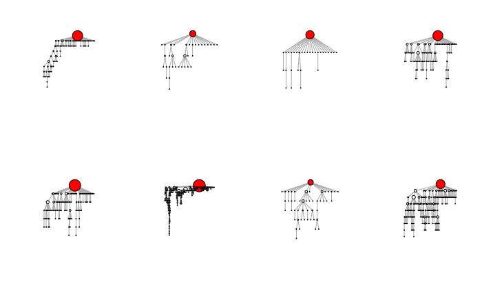

```r
# Generate threads with the estimated parameters
sizes <- (df.trees %>% group_by(thread) %>% summarise(unique = n()))$unique
sizes_sample <-  sample(sizes, length(sizes), replace=TRUE)
parents_hat.Aragon2017 <- list()
for(i in 1:length(sizes_sample)){
  parents_hat.Aragon2017[[i]] <- (gen.thread.Aragon2017(sizes_sample[i],
                                                        alpha=params.Aragon2017$alpha,
                                                        beta=params.Aragon2017$beta,
                                                        tau=params.Aragon2017$tau,
                                                        kappa=params.Aragon2017$kappa,
                                                        k=7))$parent
}
# Plot some threads in tree and graph representations
par(mfrow = c(2,4))
for(i in 1:8){
  gtree             <- parents_to_tree(parents_hat.Aragon2017[[i]])
  V(gtree)[1]$color <- "red" # except the root (initial message)
  deg <- degree(gtree, mode="all")
  gtree.un          <- as.undirected(gtree)
  la                <- layout_as_tree(gtree.un, mode='out', root=1)
  plot(gtree.un, layout = la, vertex.size=deg*1.5, vertex.label=NA)
}
```

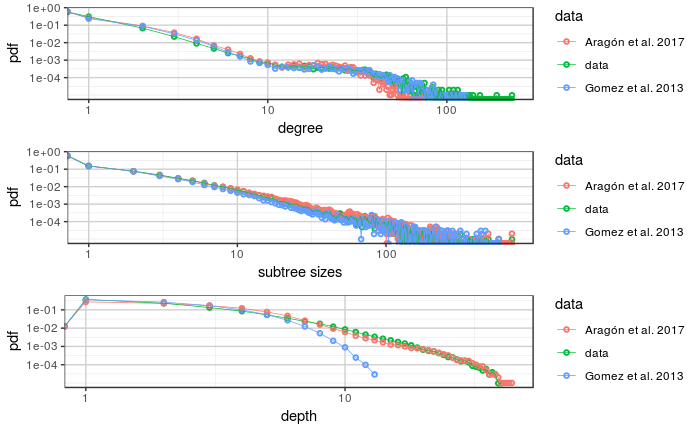

```r
# Degree distribution
df.degrees_hat.Aragon2017 <- struct_degree_distribution(parents_hat.Aragon2017)
df.degrees_hat.Aragon2017$prob <- df.degrees_hat.Aragon2017$frequency/sum(df.degrees_hat.Aragon2017$frequency)
df.degrees_hat.Aragon2017$cumprob <- cumsum(df.degrees_hat.Aragon2017$frequency/sum(df.degrees_hat.Aragon2017$frequency))
df.degrees_hat.Aragon2017$data <- 'Aragón et al. 2017'
df.degrees_all <- bind_rows(df.degrees, bind_rows(df.degrees_hat.Aragon2017, df.degrees_hat.Gomez2013))
plotdegrees <- ggplot(df.degrees_all, aes(x=degree, y=cumprob, color=data)) +
  geom_point(aes(x=degree, y = prob), shape = 21, size = 1, stroke = 1) +
  geom_line(aes(x=degree, y = prob), size=0.25) +
  scale_x_log10(breaks=c(1,10,100)) +
  scale_y_log10(breaks=c(0.0001,0.001,0.01,0.1,1)) +
  theme_bw() +
  theme(panel.grid.major = element_line(colour = "#d0d0d0")) +
  ylab('pdf')

# Subtree size distribution
df.subtrees_hat.Aragon2017 <- struct_subtree_size_distribution(parents_hat.Aragon2017)
df.subtrees_hat.Aragon2017$prob <- df.subtrees_hat.Aragon2017$frequency/sum(df.subtrees_hat.Aragon2017$frequency)
df.subtrees_hat.Aragon2017$cumprob <- cumsum(df.subtrees_hat.Aragon2017$frequency/sum(df.subtrees_hat.Aragon2017$frequency))
df.subtrees_hat.Aragon2017$data <- 'Aragón et al. 2017'
df.subtrees_all <- bind_rows(df.subtrees, bind_rows(df.subtrees_hat.Aragon2017, df.subtrees_hat.Gomez2013))
plotsubtrees <- ggplot(df.subtrees_all, aes(x=size, y=cumprob, color=data)) +
  geom_point(aes(x=size, y = prob), shape = 21, size = 1, stroke = 1) +
  geom_line(aes(x=size, y = prob), size=0.25) +
  scale_x_log10(breaks=c(1,10,100)) +
  scale_y_log10(breaks=c(0.0001,0.001,0.01,0.1,1)) +
  theme_bw() +
  theme(panel.grid.major = element_line(colour = "#d0d0d0")) +
  xlab ('subtree sizes') +
  ylab('pdf')

# Depth distribution
df.depths_hat.Aragon2017 <- struct_depth_distribution(parents_hat.Aragon2017)
df.depths_hat.Aragon2017$prob <- df.depths_hat.Aragon2017$frequency/sum(df.depths_hat.Aragon2017$frequency)
df.depths_hat.Aragon2017$cumprob <- 1-cumsum(df.depths_hat.Aragon2017$frequency/sum(df.depths_hat.Aragon2017$frequency))
df.depths_hat.Aragon2017$data <- 'Aragón et al. 2017'
df.subtrees_all <- bind_rows(df.subtrees, bind_rows(df.subtrees_hat.Aragon2017, df.subtrees_hat.Gomez2013))
df.depths_all <- bind_rows(df.depths, bind_rows(df.depths_hat.Gomez2013, df.depths_hat.Aragon2017))
plotdepths <- ggplot(df.depths_all, aes(x=depth, y=cumprob, color=data)) +
  geom_point(aes(x=depth, y = prob), shape = 21, size = 1, stroke = 1) +
  geom_line(aes(x=depth, y = prob), size=0.25) +
  scale_y_log10(breaks=c(0.0001,0.001,0.01,0.1,1)) +
  scale_x_log10(breaks=c(1,10,100)) +
  theme_bw() +
  theme(panel.grid.major = element_line(colour = "#d0d0d0")) +
  ylab('pdf')

grid.arrange(plotdegrees, plotsubtrees, plotdepths, nrow = 3)
```